# Méthode de Newton-Raphson pour la maximisation de la vraisemblance pour la régression logistique

Python works with packages. A large number of packages can be dowloaded all together in the Anaconda environment. Start downloading here (version >3) https://www.anaconda.com/download/ Anaconda comes with

- Spyder, a GUI for python
- Jupyter Notebook, how to create great documents

Enjoy!

Bee careful :

- Python is sensible to spaces in the beginning of lines,
- Python is sensible to number type : $3$ and $3.$ are totally different: *integer* and *float* types.

```python
import warnings
warnings.filterwarnings('ignore')

import numpy as np
import numpy.random as npr
import matplotlib.pyplot as plt
import pandas as pd
```

# Les données

On a un dataset formé par deux variables qualitatives binaires $X$ et $Y$. Telles que les valeurs prises par :

- $X$ : *fumeuse* ou *non fumeuse*
- $Y$ : *FPN* ou *poids normal*

Soit donc les valeurs définissant les $n$ patients $\forall i=1..n,(x_i,y_i)$.

En fait on le génère :

```python
X = [0]*115+[1]*74
Y = [1]*29+[0]*130+[1]*30
data = np.array([X,Y]).T
pd_data = pd.DataFrame(data=data,columns=["Tabagisme (X)","Poids (Y)"])
poids_tabagisme = pd.crosstab(index=pd_data["Tabagisme (X)"],
                           columns=pd_data["Poids (Y)"])
poids_tabagisme
```

| Poids (Y) Tabagisme (X) | 0 | 1 |
| --- | --- | --- |
| 0 | 86 | 29 |
| 1 | 44 | 30 |

# La méthode de Newton-Raphson

```
C'est une méthode qui permet de trouver une valeur, proche de la valeur initiale, qui annule la fonction. Elle nécessite que la fonction soit dérivable sur tous les points de l'intervalle considéré et que cette dérivée ne s'annule jamais.
```

## Intuition en uni-dimensionnel

L'idée est de trouver à chaque itération un point qui annule l'**approximation linéaire locale** de la fonction au point courant.

Equation de mise à jour de la suite :

- $x_0$ un point initial
- Pour la recherce d'un :
  - minimum : $x_{i+1}=x_i-\frac{f(x_i)}{f'(x_i)}$
  - maximum : $x_{i+1}=x_i+\frac{f(x_i)}{f'(x_i)}$

Le script suivant permet de représenter la méthode de construction de la suite. Sur ce graphique, $F_{x_i}(x)$ est la fonction tangeante à la courbe en $x_i$

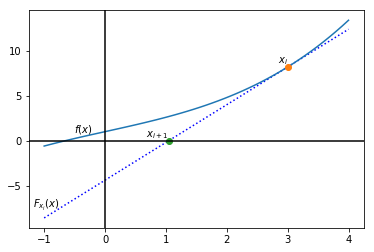

```python
import numpy as np
import matplotlib.pyplot as plt

def f_(t):
    return(.1*t**3 + 1.5*t + 1)

u = np.linspace(-1, 4)
t_0 = 3
fig, ax = plt.subplots()
ax.plot(u, f_(t_0)+(u-t_0)*(0.3*t_0**2+1.5), 'b:')
ax.plot(u, f_(u))
ax.plot(t_0, f_(t_0), marker='o')
ax.plot(t_0-f_(t_0)/(0.3*t_0**2+1.5),0, marker='o')
ax.axhline(color='black')
ax.axvline(color='black')

x=[t_0,t_0-f_(t_0)/(0.3*t_0**2+1.5),-0.2,-0.75]
y=[f_(t_0),0,0.6,-8]
labels=["$x_i$","$x_{i+1}$","$f(x)$","$F_{x_i}(x)$"]
for i, txt in enumerate(labels):
    ax.annotate(txt, (x[i], y[i]),ha='right', va='bottom')

plt.show()
```

**QUESTION** Démontrer que l'équation de mise à jour de la suite trouve bien à chaque itération le point qui annule l'approximation linéaire locale de la fonction.

Si l'approximation linéaire locale de la courbe, notée $F_{x_i}:x\rightarrow F_{x_i}(x)$ qui vérifie donc $f(x_i)=F_{x_i}(x_i)$ et $f'(x_i)=F_{x_i}'(x_i)$, s'annule en $x_{i+1}$ alors on peut écrire l'équation de la pente en $x_i$ telle que : $$ f'(x_i)=\frac{F_{x_i}(x_i)-F_{x_i}(x_{i+1})}{x_i-x_{i+1}}=\frac{f(x_i)}{x_i-x_{i+1}}, $$ en réordonnant les termes il vient $$ x_{i+1}=x_i-\frac{f(x_i)}{f'(x_i)}, $$ qui a bien la forme recherchée.

## Application au calcul de la vraisemblance

Soit un jeu de données (*dataset*) formé par deux variables **X** et **Y** telles que **Y** doit être expliqué par **X** grâce au modèle logistique suivant :

$$ \pi_i=\pi(x_i)=\frac{e^{\beta_0+\beta_1x_i}}{1+e^{\beta_0+\beta_1x_i}}, $$

on peut alors écrire

$$ (Y|X=x)\sim \mathcal{B}(\pi(x))\\ \mathbb{P}(Y=1|X=x)=\pi(x)\quad\text{et}\quad\mathbb{P}(Y=0|X=x)=1-\pi(x) $$

Le but du jeu est de qualibrer $\beta_0$ et $\beta_1$ afin que la vraissemblance du modèle soit la plus forte sachant les observations déjà récoltées. En supposant les **échantillons indépendants**, il vient que la probabilité d'observer la variable **Y** sachant la variable **X** s'écrit :

$$ \mathbb{P}(Y_1=y_1,\cdots,Y_n=y_n|X_1=x_1,\cdots,X_n=x_n) = \prod_{i=1}^n\mathbb{P}(Y_i=y_i|X_i=x_i), $$

que nous appelons **vraisemblance** et qui s'écrit ici, $\forall i\in\{1,\cdots,n\}\quad \pi_i^{y_i}(1-\pi_i)^{1-y_i}$ et donc en global

$$ \mathcal{L}(\beta_0,\beta_1|X,Y)=\prod_{i=1}^n\pi_i^{y_i}(1-\pi_i)^{1-y_i}. $$

On passe par la méthode du maximum de vraissemblance pour écrire la condition d'optimalité. On apelle alors $l(\beta_0,\beta_1|X,Y)$ la **log-vraisemblance** du problème.

On définit la matrice de **Score** associée à la fonction de $2$ variables $l(\beta_0,\beta_1|X,Y)$,

$$ \mathcal{U}(\beta_0,\beta_1|X,Y)= \begin{pmatrix} \frac{\partial l}{\partial \beta_0}(\beta_0,\beta_1|X,Y)\\ \frac{\partial l}{\partial \beta_1}(\beta_0,\beta_1|X,Y) \end{pmatrix}, $$ estimée au point de minimum $(\beta_0^\star,\beta_1^\star)$ on doit avoir $$ \mathcal{U}(\beta_0^\star,\beta_1^\star|X,Y)= \begin{pmatrix} 0\\ 0 \end{pmatrix} =0 $$

En pratique il est très compliqué de résoudre ce problème on passe donc par une méthode itérative d'approximation : **La méthode de Newton-Raphson matricielle**.

Si l'on doit résoudre le problème $\mathcal{U}(\beta_0^\star,\beta_1^\star|X,Y)=0$ et que l'on peut calculer la matrice **Hessienne** de la fonction $l$, qui s'écrit

$$ \mathcal{H}(\beta_0,\beta_1|X,Y)= \begin{pmatrix} \frac{\partial^2 l}{\partial \beta_0^2} & \frac{\partial^2 l}{\partial \beta_0\partial \beta_1}\\ \frac{\partial^2 l}{\partial \beta_0\partial \beta_1} & \frac{\partial^2 l}{\partial \beta_1^2} \end{pmatrix}, $$

alors la mise à jour par **la méthode de Newton-Raphson** s'écrit, en notant $\beta^{(i)}=\begin{pmatrix} \beta_0^{(i)}\\ \beta_1^{(i)} \end{pmatrix}$ , dans le cas à plusieurs variables :

$$\beta^{(i+1)}=\beta^{(i)}+\mathcal{H}(\beta_0^{(i)},\beta_1^{(i)}|X,Y)^{-1}\mathcal{U}(\beta_0^{(i)},\beta_1^{(i)}|X,Y).$$

**ATTENTION** : On recherche ici le **maximum** de la vraisemblance donc la descente est une montée, d'où le **+** et non pas **-**.

Les différentes fonctions s'expriment tel que :

- La **log-vraissemblance** $$ l(\beta_0,\beta_1|X,Y)=\sum_{i=1}^ny_i(\beta_0+\beta_1x_i)-log(1+e^{\beta_0+\beta_1x_i}). $$
- Son **Score** $$ \mathcal{U}(\beta_0,\beta_1|X,Y)= \begin{pmatrix} \frac{\partial l}{\partial \beta_0}\\ \frac{\partial l}{\partial \beta_1} \end{pmatrix} $$

$$ \mathcal{U}(\beta_0,\beta_1|X,Y)= \begin{pmatrix} \sum_{i=1}^ny_i-\frac{e^{\beta_0+\beta_1x_i}}{1+e^{\beta_0+\beta_1x_i}}\\ \sum_{i=1}^nx_i(y_i-\frac{e^{\beta_0+\beta_1x_i}}{1+e^{\beta_0+\beta_1x_i}}) \end{pmatrix}. $$

- Et la **Hessienne** associée $$ \mathcal{H}(\beta_0,\beta_1|X,Y)= \begin{pmatrix} \frac{\partial^2 l}{\partial \beta_0^2} & \frac{\partial^2 l}{\partial \beta_0\partial \beta_1}\\ \frac{\partial^2 l}{\partial \beta_0\partial \beta_1} & \frac{\partial^2 l}{\partial \beta_1^2} \end{pmatrix} $$

$$ \mathcal{H}(\beta_0,\beta_1|X,Y)= \begin{pmatrix} \sum_{i=1}^n\frac{e^{\beta_0+\beta_1x_i}}{(1+e^{\beta_0+\beta_1x_i})^2}& \sum_{i=1}^nx_i\frac{e^{\beta_0+\beta_1x_i}}{(1+e^{\beta_0+\beta_1x_i})^2} \\ \sum_{i=1}^nx_i\frac{e^{\beta_0+\beta_1x_i}}{(1+e^{\beta_0+\beta_1x_i})^2}& \sum_{i=1}^nx_i^2\frac{e^{\beta_0+\beta_1x_i}}{(1+e^{\beta_0+\beta_1x_i})^2} \end{pmatrix}. $$

## Application : programmation sous Python

On définit plusieurs fonctions permettant de calculer les valeurs de la fonction aux points courants.

La fonction de vraissemblance :

```python
def log_like(data,th):
    b0 = th[0]
    b1 = th[1]
    X_in = data[:,0:1]
    Y_real = data[:,1:2]
    Y_est = b0+b1*X_in
    out = np.dot(Y_real.T,Y_est)-np.sum(np.log(1+np.exp(Y_est)))[0,0]
    return(out)

def U_score(data,th):
    b0 = th[0]
    b1 = th[1]
    X_in = data[:,0:1]
    Y_real = data[:,1:2]
    exp_Y_est = np.exp(b0+b1*X_in)
    p = exp_Y_est/(1+exp_Y_est)
    delta = Y_real-p
    L_prime_0 = np.sum(delta)
    L_prime_1 = np.dot(X_in.T,delta)[0,0]
    return(np.array([[L_prime_0],[L_prime_1]]))

def Hess(data,th):
    b0 = th[0]
    b1 = th[1]
    X_in = data[:,0:1]
    exp_Y_est = np.exp(b0+b1*X_in)
    p_2 = exp_Y_est/(1+exp_Y_est)**2
    H_0_0 = np.sum(p_2)
    H_0_1 = np.dot(X_in.T,p_2)
    H_1_1 = np.dot(X_in.T**2,p_2)
    return(np.array([[H_0_0,H_0_1],[H_0_1,H_1_1]]))
```

Une fonction qui fait réellement le calcul itératif

```python
def newton_raphson(data,errorMin=1e-9,maxIter=100):
    pd_data = pd.DataFrame(data=data,columns=["X","Y"])
    crosstab = pd.crosstab(index=pd_data["X"],
                           columns=pd_data["Y"]).values
    b_0_init = np.log(crosstab[0,1]/(crosstab[1,1]))
    theta = np.array([[b_0_init],[0]])
    err = 10*errorMin
    iteration = 1
    crit = True
    while crit:
        U = U_score(data,theta)
        H = Hess(data,theta)
        theta = theta + np.dot(np.linalg.inv(H),U)
        err = np.linalg.norm(U)
        crit_1 = err>errorMin
        crit_2 = iteration<maxIter
        crit = crit_1 & crit_2
        iteration = iteration + 1
    if crit_2==False:
        print("Maximum number of iterations reached")
    return(theta)
```

Que l'on peut appliquer à notre jeu de données

```python
theta = newton_raphson(data)
print(theta)
```

```
[[-1.08705147]
 [ 0.70405921]]
```

Le **signe** de $\beta_1$ renseigne sur le lien entre **X** et **Y** : la probabilité de $Y=1$ augmente avec celle de $X=1$ lorsque $\beta_1>0$ et diminue dans l'autre cas.

Afin d'estimer la variance on utilise la matrice d'information de Fisher

```python
Info_Fisher = np.linalg.inv(Hess(data,[theta[0,0],theta[1,0]]))
std_b0 = np.sqrt(Info_Fisher[0,0])
std_b1 = np.sqrt(Info_Fisher[1,1])
print(std_b0)
print(std_b1)
```

```
0.21473394141922192
0.3196424121702874
```